[Home](https://canholyavkin.github.io) - [Other Posts](https://canholyavkin.github.io/#blog) - Contact

# İlk Sentetik Ökaryot: Sc2.0

Şimdi sıra ökaryotlarda….

Sentetik bakteriler geçtiğimiz yıla damgasını vurmuşken, bazı araştırmacılar daha büyük bir amacın peşinde önemli adımlar atıyorlar. **Yeni hedef, genomu tamamen sentetik olan ilk ökaryotik organizmayı yaratmak.**

İlk sentetik bakteri JCVI-syn1.0, [J. Craig Venter Enstitüsü](http://jcvi.org/) (JCVI) ve [Synthetic Genomics](https://www.syntheticgenomics.com/) kuruluşlarının ortak çalışması ile 2008 yılında; daha küçük genoma sahip ikinci sentetik bakteri **JCVI-syn3.0** ise 2016 yılında [duyurulmuştu](http://variantgenetik.com/minimal_genom_syn3/). Sıfırdan tüm bir genomik yapının yaratıldığı bu çalışmalar, “genomik mühendisliğin” hakkını verecek gerçek “mühendislik” adımlarıydı ve yenilerini tetiklediler. **Bunun son örneği, tamamen laboratuvar ortamında üretilmiş sentetik maya genomunun oluşturulması.** Tamamlandığında, *Saccharomyces cerevisiae* 2.0, veya daha bilinen adıyla **Sc2.0**, sentetik biyolojinin en önemli kilometre taşlarından biri olacak.

[figure not shown]

Sentetik mayanın geliştirilmesindeki gelişmeler, Science dergisinin 2017 Mart sayısının kapağında yer buldu.

# Cyborg Mayaların Yükselişi

Dahası, sentetik kromozom **synIII**, doğal kromozom 3’ten çok noktada farklıydı. Araştırmacıların yeni tasarım içinde yaptığı düzenlemeler ile **sentetik kromozom** 273, 871 bazlık uzunluğu ile orjinalinden 41.796 baz daha kısaydı.

Proje süresince, araştırma grubu kromozom üzerinde **500’den fazla değişiklik** yapmış; büyüme/üremede etkisi olmadığı düşünülen tekrarlı bölgeleri son tasarımdan çıkarmıştı. Hatta, önemi hala tartışılan **“çöp DNA” (junk DNA) parçaları, intron ve transposon parçaları da sentetik kromozom içinde yer almıyordu**. Buna rağmen, sentetik kromozoma sahip “cyborg” maya hücresi, yaşamını sürdürmeye devam etmişti. (Elbette yüzlerce deneme-yanılma sürecinden sonra.)

# Kromozomdan Genoma

Maya kromozomlarının üretimi birçok kuruma paylaştırılmış durumda. Grafikte, kurumların sorumlu olduğu bölgeler ve başarıyla tamamladıkları parçalar görülüyor. Benzeri çalışmalar, bakteride başarılı sonuç vermişti. **Ancak, 16 kromozomu ile bakteriyel genomdan 22 kat büyük bir ökaryotik genomu üretmek** çok daha zorlu bir görevdi.

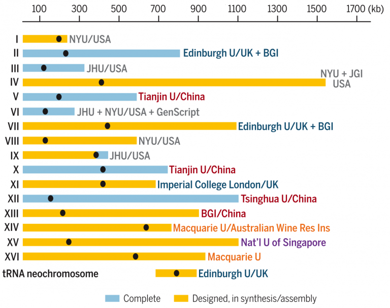

Maya kromozomlarının üretimi birçok kuruma paylaştırılmış durumda. Grafikte, kurumların sorumlu olduğu bölgeler ve başarıyla tamamladıkları parçalar görülüyor.

# Sentetik Genom Nasıl Üretiliyor?

Yürütülen projeye ait son makale henüz yayınlanmadığı için henüz kullanılan yöntemi tam olarak bilmek mümkün değil. Ancak 2014 ve 2017 yıllarında, grubun çıkardığı ara-yayınlarda 16 kromozomdan 6’sının tamamlandığı duyuruldu. [^2] Bu makalelelere göre, çalışmada şu basamaklar izleniyor:

- Bilgisayar ortamında bilinen maya genomu tekrar tasarlanıyor. Bu şekilde genom üzerindeki bazı bölgeler tasarımdan siliniyor.
- Tasarlanan yeni genom 70 harflik parçalar halinde gruplandırılıyor.
- Bu mini parçalar, DNA sentez hizmeti veren kuruluşlar tarafından sentezleniyor. (İlk çalışmada tek bir kromozomu oluşturan bu parçalardan yaklaşık 3000 tane olduğunu belirtmekte fayda var.)
- Küçük parçalar PCR işlemi ile birleştirilip 750 bazlık mini-gruplar (minichunk) oluşturuluyor.
- Bu mini-gruplar vektörler ile hücre içine aktarılıp, hücre içinde birleştirilerek 2-4 kb’lık parçalar haline getiriliyor.
- Ardından bu parçalar 30-50 kb’lık mega-parçalar olacak şekilde birleştiriliyor.
- Bu mega-parçalar, homolog rekombinasyon ile tek tek maya genomuna entegre ediliyor. Yani her defasında kromozomun bir kısmı sentetik olanı ile yer değiştiriliyor.
- Bu yer değiştirme işlemi, kromozom tamamen sentetik olana kadar devam ettiriliyor

Her bir grup kendi parçasını tamamladığında, farklı sentetik kromozomlara sahip bu farklı maya suşları arasında bir seri çifleştirme ve spor oluşumu gerçekleştirilecek. Bu şekilde genomu tamamen sentetik kromozomlardan oluşan maya oluşturulmuş olacak.

Gruplar arası ortak bir genom tasarım yaklaşımı oluşturmak için, proje kapsamında **BioStudio** ve **GBrowse** adlı uygulamalar geliştirilmiş. [^3] Bu programlar, tüm genomu sonra tekrar birleştirilebilecek parçalara ayrıştırılmasını, üzerinde yapılan değişikliklerin takibini, sentez-birleştirme işlemlerinin izlenmesini sağlamış. [^4] Proje yürütücüsü Prof. Boeke, benzeri programların olduğunu, ancak bunların genom/kromozom ölçeğinde yetersiz kaldığını; bu sebeple yeni bir program geliştirdiklerini ifade ediyor.

# Parçalı Değişim

Çalışma, birçok noktada **sentetik bakteri ile ciddi farklılıklar taşıyor**. Bunun başında senetik parçaların doğal genoma entegrasyonu geliyor.

Sentetik bakteri JCVI-syn3.0’da üretilen **bütün haldeki sentetik genom**, hücreye tek seferde aktarılmıştı. Maya genomundaki değişim ise parça parça gerçekleşiyor. **SwAP-In** adı verilen bu yaklaşımda her defada, genomun sadece küçük bir kısmı yenisi ile değiştiriliyor.

Genomun bu şekilde **parça parça yenisi ile değiştirilmesinin** birkaç avantajı oluyor. Sentetik parçaların her biri eklendikten sonra, bu yeni parçanın “cyborg” mayanın yaşamını etkileyip etkilemediği inceleniyor. Bu şekilde son değiştirilen parçada sorun olup olmadığı önceden kestirilebiliyor. Ardından eklenen parçanın dizisinde modifikasyonlar yapılarak yeniden hücreye aktarılıyor. Araştırmacıların ilettiklerine göre, projenin büyük bir kısmını bu “**hata tespiti > tekrar tasarım > entegrasyon**” oluşturuyor. [^5]

# Sıra İnsan’da mı?

Henüz çalışma başarı ile tamamlanmamış olsa da, sıradaki hedefin insan olabileceği konusu aklımıza gelmiyor değil. Ütopik sayılabilecek bir gelecekte insan genomunu sentetik olarak oluşturmak mümkün. Ama bunun (etik konuları göz ardı edersek) çok sayıda teknik zorluğu bulunuyor.

## Regülatör Bölgeler:

Maya genomunun sentetik üretimi bir kez daha gösterdi ki, ökaryotik genomlar bakteriyel olanlara göre (gerçekten) çok daha karmaşık. Bu karmaşıklık özellikle kendini genomdaki regülatör bölgelerde gösteriyor.

Regülatör bölgeler, genom üzerindeki genlerin ne oranda çalışacağını belirleyen, **bir nevi genetik vana görevi gören** bölgelerdir. Bakterilerde bu bölgeler, etkilediği genlerin hemen yanı başında olduğu için, bir genin vanasının nerede olduğu kolayca tahmin edilebilir.

Ökaryotlarda ise bu durum çok farklı. Bir genin regülatörü, başka bir kromozomun bambaşka bir konumunda yer alabilir. Bu durum, bir genin vanasının nerede olabileceği konusunda bilgimizi de kısıtlayan bir konu. Bir araştırma grubu, bir kromozomda değişiklik yaparken, bir başka kromozomda yer alan bir genin vanasını yanlışlıkla silebilir ve değiştirebilir. Ve sorunu tespit etmek yıllar alabilir. Maya genomunda iş böyleyken, 500 kat büyük insan genomunu hayal edin.

# Sonrası:

Sentetik biyoloji, yeni gerçekleştirilen devasa projeler ile **“teorik” bir bilim olmaktan çıkıp “pratik” uygulamalara dönüşmeye** başlıyor. Benzeri çalışmaların sayısı arttıkça, yapay DNA parçalarının tasarlanıp üretilmesi ve bunların canlı bir organizmaya aktarılması konusunda tecrübemiz daha da artacak. Bu şekilde insan genetik hastalıkların model organizmalarda daha iyi kurgulayarak sağlayarak, kalıtımsal hastalıkları daha iyi anlayabileceğiz.

Bu projeleri, çok hücrelilere ait sentetik genomların takip edeceğini tahmin etmek zor değil. Bu durumda, yüzleşeceğimiz yeni teknik ve etik sorunlar ortaya çıkacaktır. Her halükarda “Sentetik biyoloji” çok da uzun olmayan bir gelecekte, gündelik hayatımızda kullandığımız kelimelerin arasına girecek. Atılan bu küçük adımların gelecekteki etkilerinin ne olacağını ise bize zaman gösterecek.

[^1]: Annaluru, N. vd. Total Synthesis of a Functional Designer Eukaryotic Chromosome. Science 344, 55–58 (2014).
[^2]: Richardson, S. M. vd. Design of a synthetic yeast genome. Science 355, 1040–1044 (2017).
[^3]: GMOD. Sourceforge Available at: https://sourceforge.net/projects/gmod/files/Generic%20Genome%20Browser/.
[^4]: Designer Yeast. Deixis Magazine Available at: https://deixismagazine.org/2011/09/designer-yeast/.
[^5]: Perkel, J. M. Cell engineering: How to hack the genome. Nature 547, 477–479 (2017).

**Can Holyavkin**

E-posta | [Linkedin](https://www.linkedin.com/in/can-holyavkin/) | [Twitter](https://twitter.com/CanHolyavkin)